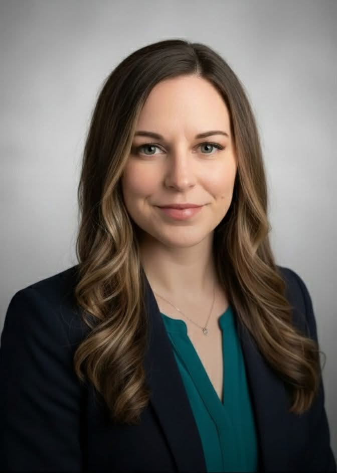

Rachel Cook is a statistical data scientist with over five years of experience in R, SQL, ArcGIS, and Tableau.

She has demonstrated proficiency in handling large and intricate datasets exceeding 60 million datapoints across a variety of servers and databases. Her expertise in SQL, R, and Excel allows her to effectively query data from diverse sources, including cloud, network, and local databases. Her skillset encompasses data cleaning, manipulation, and advanced statistical modeling to deliver accurate and insightful analysis.

Rachel has proven experience in designing and maintaining both internal and public-facing dashboards through RShiny, ArcGIS, and Tableau. With these tools, she has successfully transformed raw data into interactive visual representations for stakeholders, facilitating navigation and understanding for broader audiences. This dashboard, which utilizes RShiny and RMarkdown, is a representational example of her skillset.

During her time in the research domain, Rachel contributed to scientific literature by publishing three papers in peer-reviewed journals. She has effectively communicated the complex mathematical and scientific findings to diverse audiences by presenting them at conferences, showcasing her ability to bridge the gap between technical concepts and everyday language.

Rachel possesses two master’s degrees, along with the Google Data Analytics Professional Certificate, reinforcing her commitment to continuous learning and skill development. With a lifelong passion for learning, she is dedicated to continuously honing her craft.

Please click on following links to read more:

[LinkedIn](https://www.linkedin.com/in/cook-rachel/)  
[GitHub](https://github.com/cook-rachel)  
[Tableau](https://public.tableau.com/app/profile/rachelcook)